# Advanced Classification - Part 2

One should look for what is and not what he thinks should be. (Albert Einstein)

# Module completion checklist

| Objective | Complete |
| --- | --- |
| Predict using random forest model and evaluate results |  |
| Introduce gradient boosting and how it compares to bagging |  |
| Discuss gradient tree boosting within scikit-learn and implement on Costa Rican data |  |

# Loading packages

- Let’s load the packages we will be using
- These packages are used for classification using gradient boosting and other tools

```python
import os
import pickle
import matplotlib.pyplot as plt
import numpy as np
import pandas as pd
from pathlib import Path
from textwrap import wrap
from sklearn.model_selection import train_test_split
from sklearn import metrics

# Random forest and boosting packages
from sklearn.ensemble import RandomForestClassifier
from sklearn.ensemble import GradientBoostingClassifier
```

# Recap: random forest

- What is a random forest?
  - Ensemble method used for **classification and regression tasks**
  - Supervised learning algorithm which builds **multiple decision trees** and aggregates the result
  - Uses a technique called Bootstrap Aggregation, commonly known as Bagging
  - Limits overfitting and bias error

# Recap: building the forest

The two main parameters we need to set to build a random forest are:

1. Number of trees
2. Number of features per tree

We can stick with these rules:

1. **N of trees** - the more the better, but a good rule of thumb is $n\approx{100}$, where $n =$ $number$ $of$ $trees$
2. N of features per tree - the rule of thumb here is $m=\sqrt{p}$, where $p =$ $number$ $of$ $predictors$

# Datasets for today

- **We will be using the same datasets as earlier tiday, one for in-class practice and the other for self guided-exercise work**
- A dataset in class to learn the concepts
  - Costa Rica household poverty data by the Inter-American Development Bank
- **A dataset for our in-class exercises**
  - Bank marketing dataset
    - Related to direct marketing campaigns of a Portuguese banking institution
    - The target variable is whether the user subscribed to the bank term deposit (‘yes’) or not (‘no’)

# Directory settings

- In order to maximize the efficiency of your workflow, you should encode your directory structure into `variables`
- We will use the `pathlib` library
- Let the `main_dir` be the variable corresponding to your `course` folder
- Let `data_dir` be the variable corresponding to your `data` folder

```python
# Set 'main_dir' to location of the project folder
home_dir = Path(".").resolve()
main_dir = home_dir.parent.parent
print(main_dir)
```

```python
data_dir = str(main_dir) + "/data"
print(data_dir)
```

# Load the cleaned dataset

- Let’s load the dataset from earlier today: `costa_clean`
- Assign it to `costa_clean` variable

```python
costa_clean = pickle.load(open(data_dir + "/costa_clean.sav","rb"))
print(costa_clean.head())
```

```
   rooms  tablet  males_under_12  ...  rural_zone  age  Target
0      3       0               0  ...           0   43    True
1      4       1               0  ...           0   67    True
2      8       0               0  ...           0   92    True
3      5       1               0  ...           0   17    True
4      5       1               0  ...           0   37    True

[5 rows x 81 columns]
```

# Print info for our data

- Let’s view the column names

```python
costa_clean.columns
```

```
Index(['rooms', 'tablet', 'males_under_12', 'males_over_12', 'males_tot',
       'females_under_12', 'females_over_12', 'females_tot', 'ppl_under_12',
       'ppl_over_12', 'ppl_total', 'years_of_schooling', 'wall_block_brick',
       'wall_socket', 'wall_prefab_cement', 'wall_wood', 'floor_mos_cer_terr',
       'floor_cement', 'floor_wood', 'ceiling', 'electric_public',
       'electric_coop', 'toilet_sewer', 'toilet_septic', 'cookenergy_elec',
       'cookenergy_gas', 'trash_truck', 'trash_burn', 'wall_bad', 'wall_reg',
       'wall_good', 'roof_bad', 'roof_reg', 'roof_good', 'floor_bad',
       'floor_reg', 'floor_good', 'disabled_ppl', 'male', 'female', 'under10',
       'free', 'married', 'separated', 'single', 'hh_head', 'hh_spouse',
       'hh_child', 'num_child', 'num_adults', 'num_65plus', 'num_hh_total',
       'dependency_rate', 'male_hh_head_educ', 'female_hh_head_educ',
       'meaneduc', 'educ_none', 'educ_primary_inc', 'educ_primary',
       'educ_secondary_inc', 'educ_secondary', 'educ_undergrad', 'bedrooms',
       'ppl_per_room', 'house_owned_full', 'house_owned_paying',
       'house_rented', 'house_other', 'computer', 'television',
       'num_mobilephones', 'region_central', 'region_Chorotega',
       'region_pacifico', 'region_brunca', 'region_antlantica',
       'region_huetar', 'urban_zone', 'rural_zone', 'age', 'Target'],
      dtype='object')
```

# Split into training and test sets

```python
# Select the predictors and target.
X = costa_clean.drop(['Target'], axis = 1)
y = np.array(costa_clean['Target'])

# Set the seed to 1.
np.random.seed(1)

# Split into the training and test sets.
X_train, X_test, y_train, y_test = train_test_split(X, y, test_size = 0.3)
```

# Building our model

- Let’s build our random forest model and use all default parameters for now, as our baseline model

```python
forest = RandomForestClassifier(criterion = 'gini',
                                n_estimators = 100,
                                random_state = 1)
```

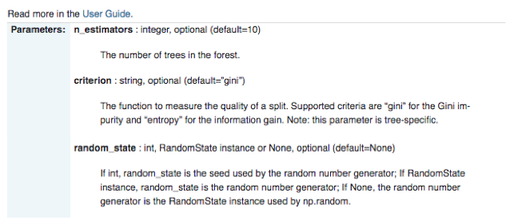

# Fitting our model

- Fit the model to the training data

```python
# Fit the saved model to your training data.
forest.fit(X_train, y_train)
```

```
RandomForestClassifier(random_state=1)
```

# Predicting with our data

- We will predict on the test data using our trained model
- The result is a vector of the predictions

```python
# Predict on test data.
y_predict_forest = forest.predict(X_test)

# Look at the first few predictions.
print(y_predict_forest[0:5,])
```

```
[ True  True  True  True  True]
```

# Confusion matrix: what is it

- A confusion matrix is what we use to measure error
- We use it to calculate Accuracy, Misclassification rate, True positive rate, False positive rate, and Specificity
- In the matrix overview of our data, let `Y1` be “non-vulnerable” and `Y2` be “vulnerable”

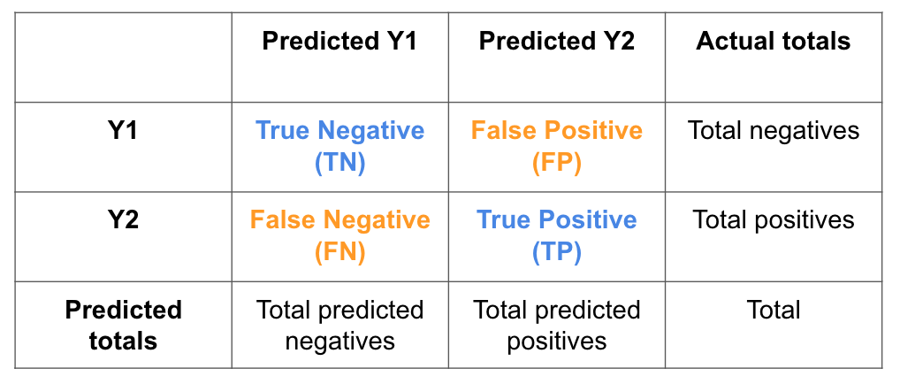

# Confusion matrix: summary

- Here is a table with all the metrics in one place:

| Metric name | Formula |
| --- | --- |
| Accuracy | True positive + True Negative / Overall total |
| Misclassification rate | False positive + False Negative / Overall total |
| True positive rate | True positive / Actual yes (True positive + False negative) |
| False positive rate | False positive / Actual no (False positive + True negative) |
| Specificity | True negative / Actual no (False positive + True negative) |

- We will use `Accuracy` to compare model performance in this module

# Confusion matrix and accuracy

Both `confusion_matrix` and `accuracy_score` take two arguments:

1. Original data labels
2. Predicted labels

```python
# Take a look at test data confusion matrix.
conf_matrix_forest = metrics.confusion_matrix(y_test, y_predict_forest)
print(conf_matrix_forest)
```

```
[[ 941  121]
 [  40 1766]]
```

```python
accuracy_forest = metrics.accuracy_score(y_test, y_predict_forest)
print("Accuracy for random forest on test data: ", accuracy_forest)
```

```
Accuracy for random forest on test data:  0.943863319386332
```

# Accuracy of the training dataset

- Let’s look at the accuracy of the model we just built, on the training data

```python
# Compute accuracy using training data.
acc_train_forest = forest.score(X_train, y_train)

print ("Train Accuracy:", acc_train_forest)
```

```
Train Accuracy: 1.0
```

- 1.0 is high for accuracy.
- Remember, this is accuracy on the training dataset. This could mean that our model is overfitting.
- We saw that our accuracy on the **test** dataset is lower, at ~ `0.94`

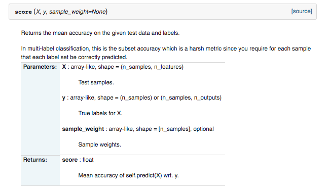

# Evaluation of Random forest

- Let’s store the accuracy of this model:

```python
# Create a dictionary with accuracy values for our\ random forest model.
model_final_dict = {'metrics': ["accuracy"],
               'values':[round(accuracy_forest,4)],
                'model':['random_forest']}
model_final = pd.DataFrame(data = model_final_dict)
print(model_final)
```

```
    metrics  values          model
0  accuracy  0.9439  random_forest
```

- As we move forward, we will record our metrics for each new model we build
- This way, we can compare all classification models and evaluate which one seems to be the *model champion*

# Utilizing feature importance

- One benefit of random forests and gradient boosting is that we can look at feature importance
- Often times the audience is interested in the outcome, but may not want to understand the details of the algorithm
- Therefore, **illustrating** findings through **visualizations** can make them more accessible to your audience
- A feature importance plot will show the importance of the feature based on:
  - a decrease or an increase in rate of error; or
  - gain in impurity measure that is present when the feature is present

# Applying feature importance on our data

- Suppose we would like to focus more on certain features within our data
- You should find the importance of the feature accordingly by rate of error or gain in impurity measure
- This will allow for a clearer understanding of our algorithm to another person and potentially a larger audience

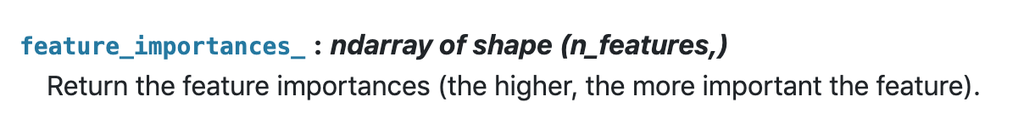

# Subsetting our features

- Let’s subset the features into another variable named `costarica_features`

```python
costarica_features = costa_clean.drop('Target', axis = 1)
```

- Here is our feature importance plot for the random forest we just built

```python
features = costarica_features.columns
importances = forest.feature_importances_
indices = np.argsort(importances)[::-1]
top_indices = indices[0:10][::-1]

plt.figure(1)
plt.title('Feature Importance')
plt.barh(range(len(top_indices)), importances[top_indices], color = 'b', align = 'center')
labels = features[top_indices]
labels = [ '\n'.join(wrap(l,13)) for l in labels ]
plt.yticks(range(len(top_indices)), labels)
plt.xlabel('Relative Importance')
```

- We will compare it to gradient boosting at the end of this module

# Feature importance plot

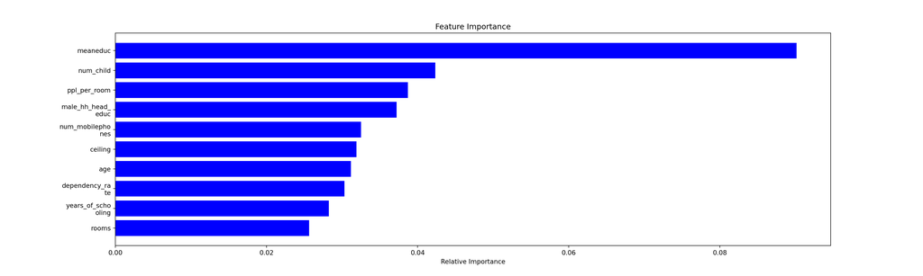

# Knowledge Check 1

# Exercise 1

# Module completion checklist

| Objective | Complete |
| --- | --- |
| Predict using random forest model and evaluate results | **✔** |
| Introduce gradient boosting and how it compares to bagging |  |
| Discuss gradient tree boosting within scikit-learn and implement on Costa Rican data |  |

# Summary

- Today we learned about:
  - concept of Random forests
  - building a simple random forest model on our data
- In the next session, we will:
  - learn about gradient boosting model
  - optimize the random forest model and compare the optimized model to the base model

# Warm up

- Before we start, check out this article on using boosted random forests to predict COVID-19 patient health: [link](https://www.frontiersin.org/articles/10.3389/fpubh.2020.00357/full)

# Welcome back

# Gradient boosted trees

- **Boosting**
  - Ensemble method, or a combination of many models on the same dataset
  - The primary focus of boosting is to combine many weak learners into one strong learner
  - New predictors are made from the **mistakes of the previous predictors**

# Gradient boosted trees

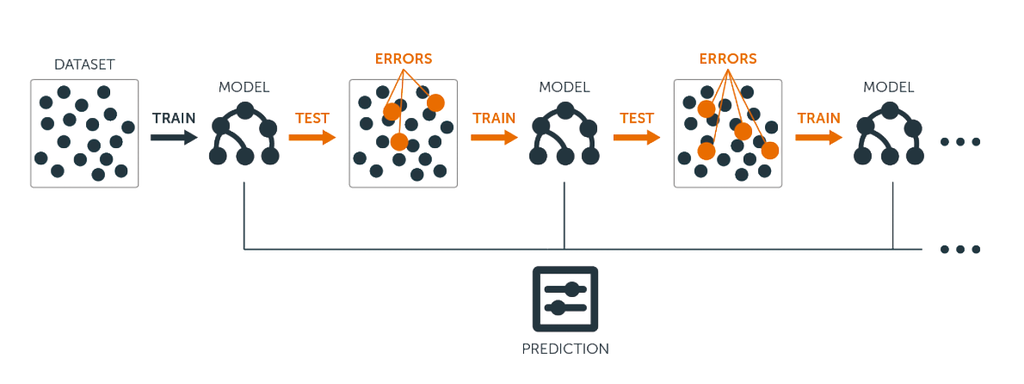

[Source](https://blog.bigml.com/2017/03/14/introduction-to-boosted-trees/)

# Boosting vs bagging

|  | Bagging | Boosting |
| --- | --- | --- |
| **Partitioning of the data into subsets** | Random | Gives mis-classified samples higher preference |
| **Goal** | Minimize variance | Increase predictive force |
| **Function to combine single models** | Weighted average | Weighted majority vote |

# Boosting vs bagging

- Unlike bagging, predictors are not made independently, but **sequentially**

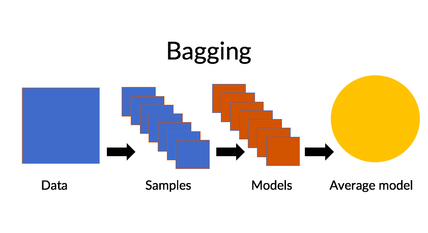

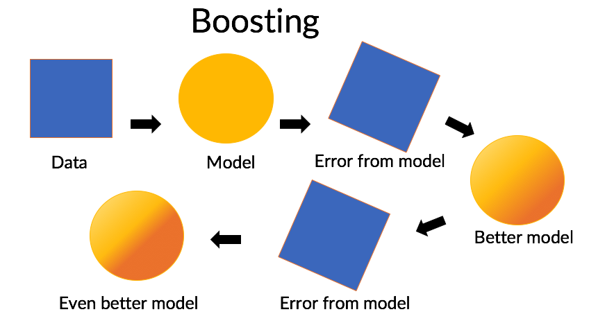

# Gradient boosting applied to decision trees

- In simple linear regression, you can clearly see the residuals, which are the multiple points around the linear model
- Let’s think of these residuals, but apply the concept to decision trees
- When gradient boosting uses decision trees, it follows these three steps:
  - Sees the errors from a decision tree on the dataset
  - **Identifies the pattern** of the errors and builds a new decision tree on them
  - Repetitively leverages these patterns in residuals to strengthen the overall model

# Gradient boosting process

- The process of gradient boosting is math heavy and complex
- However, for now, it can be simplified to three steps that we just discussed:
  1. Fit a decision tree model to the data
  2. Fit a decision tree model to the residuals
  3. Create a new model
- **Gradient boosting** can be used with classification or regression
- The generalization of the multiple weak learners occurs by the optimization of a differentiable loss function
- The loss function will change based on the model’s target variable:
  - **Regression**: [gradient descent](https://en.wikipedia.org/wiki/Gradient_descent) used to minimize mean squared error
  - **Binary classification**: [logistic function](https://en.wikipedia.org/wiki/Logistic_function)

# Module completion checklist

| Objective | Complete |
| --- | --- |
| Predict using random forest model and evaluate results | **✔** |
| Introduce gradient boosting and how it compares to bagging | **✔** |
| Discuss gradient tree boosting within scikit-learn and implement on Costa Rican data |  |

# scikit-learn - Gradient Tree Boosting

- We will be using the `GradientBoostingClassifier` library from `scikit-learn`

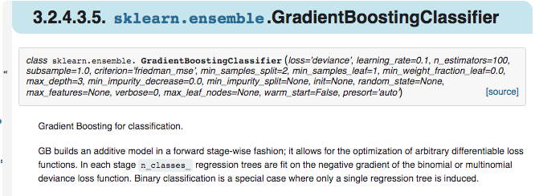

- Gradient boosting builds an additive model in a sequential fashion
- It allows for the optimization of arbitrary differentiable loss functions
- In each stage, `n_classes_` regression trees are fit on the negative gradient of the binomial or multinomial deviance loss function
- Binary classification is a special case where only a single regression tree is induced
- For all the parameters of the `GradientBoostingClassifier` package, visit [scikit-learn’s documentation](http://scikit-learn.org/stable/modules/generated/sklearn.ensemble.GradientBoostingClassifier.html#sklearn.ensemble.GradientBoostingClassifier)

# GradientBoostingClassifier

- We just introduced the package `GradientBoostingClassifier`
- We are now going to implement gradient boosting on our cleaned data
- First, let’s look at the **methods** available once the model is built

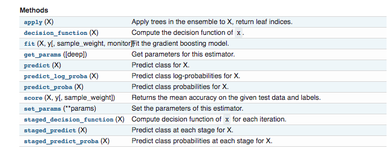

- We will perform the following steps:
  - **Build** the gradient boosting model
  - Fit the model to the training data
  - **Predict** on the test data using our trained model
  - Store the predictions to revisit later on, using `pickle`

# Boosting: build model

- **Build** the gradient boosting model

```python
# Save the parameters we will be using for our gradient boosting classifier.
gbm = GradientBoostingClassifier(n_estimators = 200,
                                learning_rate = 1,
                                max_depth = 2,
                                random_state = 1)
```

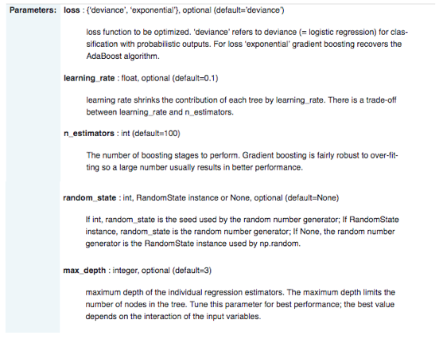

# Boosting: fit model

- Fit the model to the training data

```python
# Fit the saved model to your training data.
gbm.fit(X_train, y_train)
```

```
GradientBoostingClassifier(learning_rate=1, max_depth=2, n_estimators=200,
                           random_state=1)
```

# Boosting: predict

- We will predict on the test data using our trained model
- The result is a vector of the predictions

```python
# Predict on test data.
predicted_values_gbm = gbm.predict(X_test)
print(predicted_values_gbm)
```

```
[ True  True  True ...  True  True False]
```

# Confusion matrix and accuracy

Both `confusion_matrix` and `accuracy_score` take 2 arguments:

1. Original data labels
2. Predicted labels

```python
# Take a look at test data confusion matrix.
conf_matrix_boosting = metrics.confusion_matrix(y_test, predicted_values_gbm)
print(conf_matrix_boosting)
```

```
[[ 854  208]
 [ 155 1651]]
```

```python
# Compute test model accuracy score.
accuracy_gbm = metrics.accuracy_score(y_test, predicted_values_gbm)
print('Accuracy of gbm on test data: ', accuracy_gbm)
```

```
Accuracy of gbm on test data:  0.8734309623430963
```

# Accuracy of training model

- Let’s look at the accuracy of the model we just built, on the training data

```python
# Compute accuracy using training data.
train_accuracy_gbm = gbm.score(X_train, y_train)

print ("Train Accuracy:", train_accuracy_gbm)
```

```
Train Accuracy: 0.9165794588129765
```

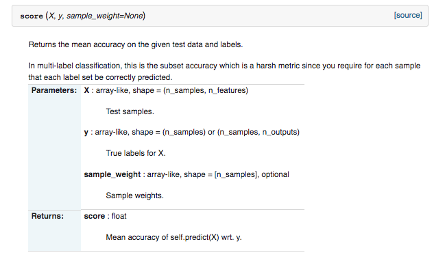

# Pickle final accuracy

- Let’s save our gradient boosting score in our `model_final` dataset
- We can see that the gbm model did not perform as well as random forest
- **We will run the vanilla models and optimize them in the next class!**

```python
# Add the model to our dataframe.
model_final_forest_gbm = model_final.append(
                        {'metrics' : "accuracy" ,
                        'values' : round(accuracy_gbm,4),
                        'model': 'boosting' } ,
                        ignore_index = True)

print(model_final_forest_gbm)
```

```
    metrics  values          model
0  accuracy  0.9439  random_forest
1  accuracy  0.8734       boosting
```

# Our top 10 features

- Here is our feature importance plot for the gradient boosting model we just built
- We are looking at the top 10 features

```python
features = costarica_features.columns
importances = gbm.feature_importances_
indices = np.argsort(importances)[::-1]
top_indices = indices[0:10][::-1]

plt.figure(1)
plt.title('Feature Importance')
plt.barh(range(len(top_indices)), importances[top_indices], color = 'b', align = 'center')
labels = features[top_indices]
labels = [ '\n'.join(wrap(l,13)) for l in labels ]
plt.yticks(range(len(top_indices)), features[top_indices])
plt.xlabel('Relative Importance')
```

# Feature importance plot

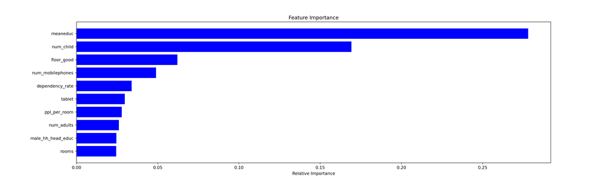

# Compare feature importance plots

- **Random forest feature importance**

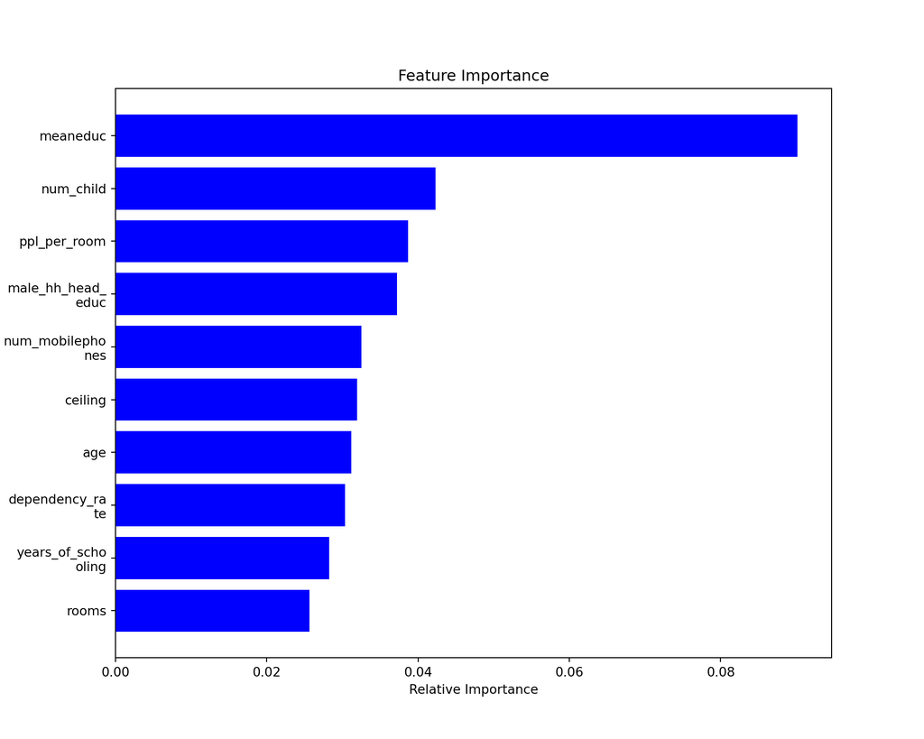

- GBM plot looks different because of the entire training set being used vs OOB predictors
- Gradient boosting feature importance

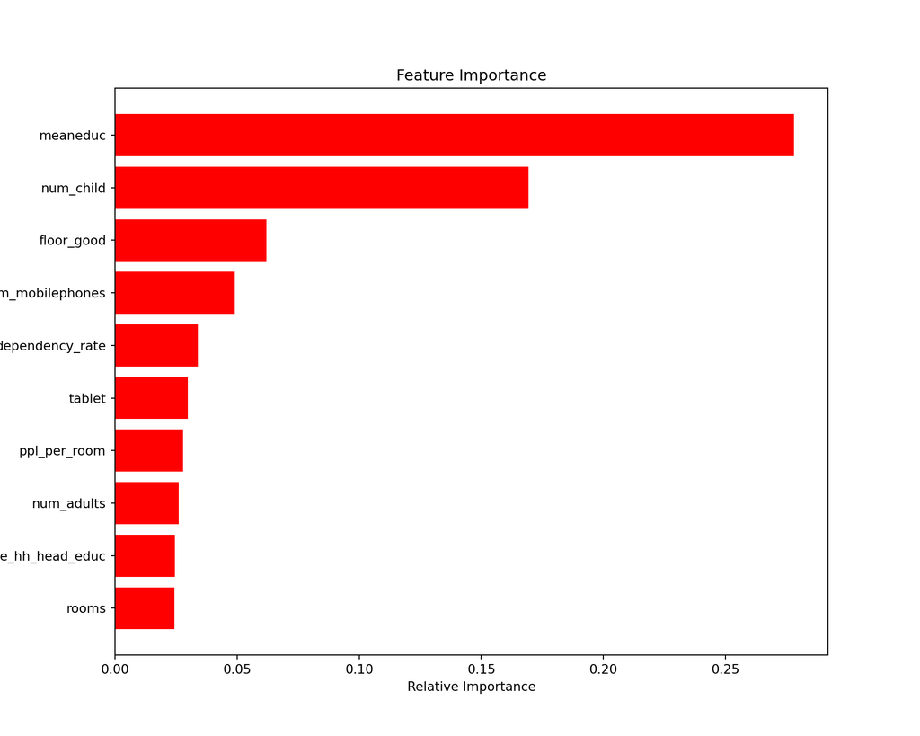

- In the next class we will be using various techniques to **optimize our ensemble methods**

# Knowledge Check 2

# Exercise 2

# Module completion checklist

| Objective | Complete |
| --- | --- |
| Predict using random forest model and evaluate results | **✔** |
| Introduce gradient boosting and how it compares to bagging | **✔** |
| Discuss gradient tree boosting within scikit-learn and implement on Costa Rican data | **✔** |

# Congratulations on completing this module!